# Biostat 203B Homework 1

Due Jan 21 @ 11:59PM

Yenlin Lai

## Q1. Git/GitHub

**No handwritten homework reports are accepted for this course.** We work with Git and GitHub. Efficient and abundant use of Git, e.g., frequent and well-documented commits, is an important criterion for grading your homework.

1. Apply for the [Student Developer Pack](https://education.github.com/pack) at GitHub using your UCLA email. You’ll get GitHub Pro account for free (unlimited public and private repositories).
2. Create a **private** repository `biostat-203b-2022-winter` and add `Hua-Zhou` and `maschepps` as your collaborators with write permission.
3. Top directories of the repository should be `hw1`, `hw2`, … Maintain two branches `main` and `develop`. The `develop` branch will be your main playground, the place where you develop solution (code) to homework problems and write up report. The `main` branch will be your presentation area. Submit your homework files (R markdown file `Rmd`, `html` file converted from R markdown, all code and extra data sets to reproduce results) in `main` branch.
4. After each homework due date, teaching assistant and instructor will check out your main branch for grading. Tag each of your homework submissions with tag names `hw1`, `hw2`, … Tagging time will be used as your submission time. That means if you tag your `hw1` submission after deadline, penalty points will be deducted for late submission.
5. After this course, you can make this repository public and use it to demonstrate your skill sets on job market.

## Q2. Data ethics training

This exercise (and later in this course) uses the [MIMIC-IV data](https://mimic-iv.mit.edu), a freely accessible critical care database developed by the MIT Lab for Computational Physiology. Follow the instructions at https://mimic.mit.edu/docs/gettingstarted/ to (1) complete the CITI `Data or Specimens Only Research` course and (2) obtain the PhysioNet credential for using the MIMIC-IV data. Display the verification links to your completion report and completion certificate here. (Hint: The CITI training takes a couple hours and the PhysioNet credentialing takes a couple days; do not leave it to the last minute.)

**Solution:** Here are the verification link of CITI course https://www.citiprogram.org/verify/?we89b7cca-0072-414d-aaba-aea012145240-46593790, and the report link of CITI course https://www.citiprogram.org/verify/?k21bb5d5a-e846-4a9c-8c32-e666926391cf-46593790. The PhysioNet credential for using the MIMIC-IV data is still processing. Below is the screenshot of my credentialing application.

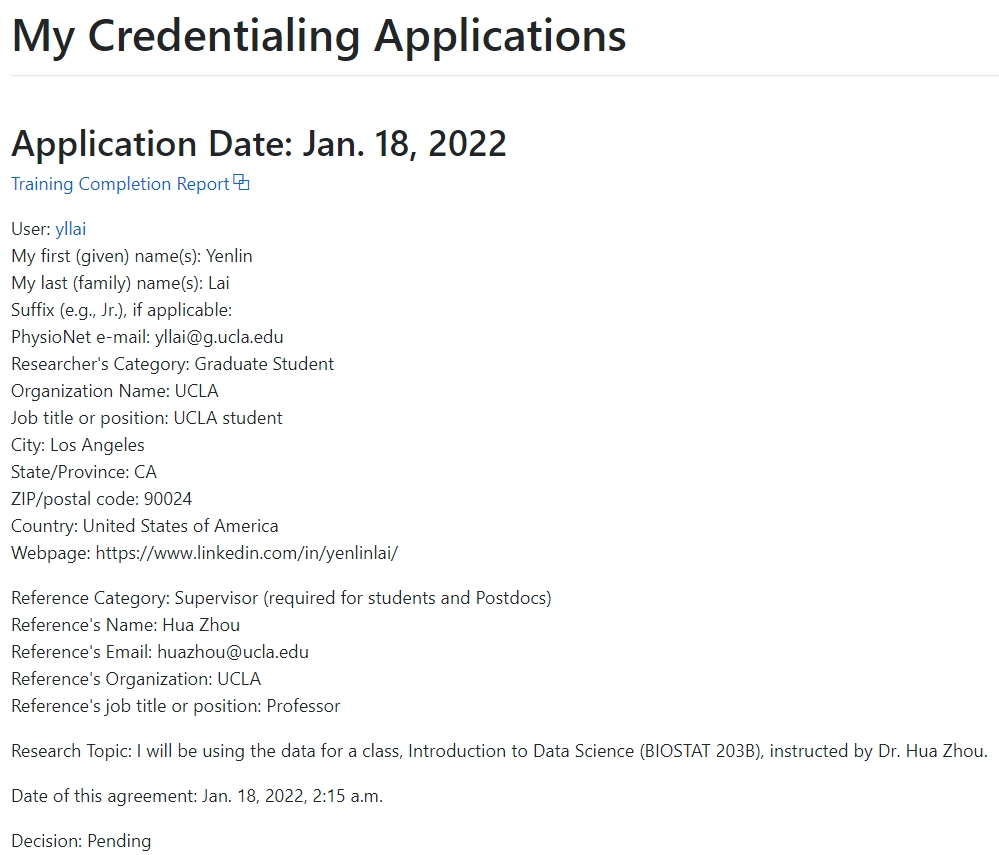

## Q3. Linux Shell Commands

1. The `/mnt/mimiciv/1.0` folder on teaching server contains data sets from MIMIC-IV. Refer to the documentation https://mimic.mit.edu/docs/iv/ for details of data files.

   ```bash
   ls -l /mnt/mimiciv/1.0
   ```

   ```
   ## total 24
   ## drwxr-xr-x. 2 root root 4096 Jan  4 21:48 core
   ## drwxr-xr-x. 2 root root 4096 Jan  4 21:51 hosp
   ## drwxr-xr-x. 2 root root 4096 Jan  4 21:52 icu
   ## -rw-r--r--. 1 root root  797 Jan  4 21:48 index.html
   ## -rw-r--r--. 1 root root 2518 Jan  4 21:54 LICENSE.txt
   ## -rw-r--r--. 1 root root 2459 Jan  4 21:48 SHA256SUMS.txt
   ```

   Please, do **not** put these data files into Git; they are big. Do **not** copy them into your directory. Do **not** decompress the gz data files. These create unnecessary big files on storage and are not big data friendly practices. Just read from the data folder `/mnt/mimiciv/1.0` directly in following exercises.

   Use Bash commands to answer following questions.
2. Display the contents in the folders `core`, `hosp`, `icu`. Why are these data files distributed as `.csv.gz` files instead of `.csv` (comma separated values) files? Read the page https://mimic.mit.edu/docs/iv/ to understand what’s in each folder.

**Solution:** Content of the folder `core` is

```bash
ls -l /mnt/mimiciv/1.0/core
```

```
## total 71472
## -rw-r--r--. 1 root root 17208966 Jan  4 21:48 admissions.csv.gz
## -rw-r--r--. 1 root root      606 Jan  4 21:48 index.html
## -rw-r--r--. 1 root root  2955582 Jan  4 21:48 patients.csv.gz
## -rw-r--r--. 1 root root 53014503 Jan  4 21:48 transfers.csv.gz
```

Content of the folder `hosp` is

```bash
ls -l /mnt/mimiciv/1.0/hosp
```

```
## total 4454012
## -rw-r--r--. 1 root root     430049 Jan  4 21:51 d_hcpcs.csv.gz
## -rw-r--r--. 1 root root   29531152 Jan  4 21:48 diagnoses_icd.csv.gz
## -rw-r--r--. 1 root root     863239 Jan  4 21:48 d_icd_diagnoses.csv.gz
## -rw-r--r--. 1 root root     579998 Jan  4 21:48 d_icd_procedures.csv.gz
## -rw-r--r--. 1 root root      14898 Jan  4 21:48 d_labitems.csv.gz
## -rw-r--r--. 1 root root   11684062 Jan  4 21:51 drgcodes.csv.gz
## -rw-r--r--. 1 root root  515763427 Jan  4 21:51 emar.csv.gz
## -rw-r--r--. 1 root root  476252563 Jan  4 21:48 emar_detail.csv.gz
## -rw-r--r--. 1 root root    2098831 Jan  4 21:51 hcpcsevents.csv.gz
## -rw-r--r--. 1 root root       2325 Jan  4 21:48 index.html
## -rw-r--r--. 1 root root 2091865786 Jan  4 21:50 labevents.csv.gz
## -rw-r--r--. 1 root root   99133381 Jan  4 21:48 microbiologyevents.csv.gz
## -rw-r--r--. 1 root root  422874088 Jan  4 21:48 pharmacy.csv.gz
## -rw-r--r--. 1 root root  501381155 Jan  4 21:51 poe.csv.gz
## -rw-r--r--. 1 root root   24020923 Jan  4 21:48 poe_detail.csv.gz
## -rw-r--r--. 1 root root  367041717 Jan  4 21:49 prescriptions.csv.gz
## -rw-r--r--. 1 root root    7750325 Jan  4 21:48 procedures_icd.csv.gz
## -rw-r--r--. 1 root root    9565293 Jan  4 21:48 services.csv.gz
```

Content of the folder `icu` is

```bash
ls -l /mnt/mimiciv/1.0/icu
```

```
## total 2741332
## -rw-r--r--. 1 root root 2350783547 Jan  4 21:54 chartevents.csv.gz
## -rw-r--r--. 1 root root   43296273 Jan  4 21:52 datetimeevents.csv.gz
## -rw-r--r--. 1 root root      55917 Jan  4 21:52 d_items.csv.gz
## -rw-r--r--. 1 root root    2848628 Jan  4 21:52 icustays.csv.gz
## -rw-r--r--. 1 root root       1103 Jan  4 21:52 index.html
## -rw-r--r--. 1 root root  352443512 Jan  4 21:52 inputevents.csv.gz
## -rw-r--r--. 1 root root   37095672 Jan  4 21:52 outputevents.csv.gz
## -rw-r--r--. 1 root root   20567368 Jan  4 21:52 procedureevents.csv.gz
```

Those files from MIMIC-IV are too big so that they needed to be compressed. `.csv.gz` files are `.csv` files compressed with gzip utility.

3. Briefly describe what bash commands `zcat`, `zless`, `zmore`, and `zgrep` do.

**Solution:**  
`zcat`: It allows us to view the contents of a compressed file without uncompressing it. It expands a compressed file to standard output allowing us to have a look at its contents.  
`zless`: It is a filter which allows paginating a compressed file and examination of compressed or plain text files one screenful at a time on a soft-copy terminal. It allows us to view files as a single file when switching between lines.  
`zmore`: It is a filter which allows paginating a compressed file examination of compressed or plain text files one screenful at a time on a soft-copy terminal. It allows us to view files as a single file separated by lines.  
`zgrep`: It allows us to search inside a compressed file without uncompressing it.

4. What’s the output of following bash script?

   ```bash
   for datafile in /mnt/mimiciv/1.0/core/*.gz
     do
       ls -l $datafile
     done
   ```

   ```
   ## -rw-r--r--. 1 root root 17208966 Jan  4 21:48 /mnt/mimiciv/1.0/core/admissions.csv.gz
   ## -rw-r--r--. 1 root root 2955582 Jan  4 21:48 /mnt/mimiciv/1.0/core/patients.csv.gz
   ## -rw-r--r--. 1 root root 53014503 Jan  4 21:48 /mnt/mimiciv/1.0/core/transfers.csv.gz
   ```

   Display the number of lines in each data file using a similar loop.

**Solution:**  
The number of lines in `admissions.csv.gz`, `patients.csv.gz`, and `transfers.csv.gz` are 523741, 382279, 2189536, respectively.

```bash
for datafile in /mnt/mimiciv/1.0/core/*.gz
  do
     echo $datafile:
     zcat $datafile | wc -l
  done
```

```
## /mnt/mimiciv/1.0/core/admissions.csv.gz:
## 523741
## /mnt/mimiciv/1.0/core/patients.csv.gz:
## 382279
## /mnt/mimiciv/1.0/core/transfers.csv.gz:
## 2189536
```

5. Display the first few lines of `admissions.csv.gz`. How many rows are in this data file? How many unique patients (identified by `subject_id`) are in this data file? (Hint: combine Linux commands `zcat`, `head`/`tail`, `awk`, `sort`, `uniq`, `wc`, and so on.)

**Solution:** The first ten lines of `admissions.csv.gz` are shown below.

```bash
   cd  /mnt/mimiciv/1.0/core
   zcat admissions.csv.gz | head -10
```

```
## subject_id,hadm_id,admittime,dischtime,deathtime,admission_type,admission_location,discharge_location,insurance,language,marital_status,ethnicity,edregtime,edouttime,hospital_expire_flag
## 14679932,21038362,2139-09-26 14:16:00,2139-09-28 11:30:00,,ELECTIVE,,HOME,Other,ENGLISH,SINGLE,UNKNOWN,,,0
## 15585972,24941086,2123-10-07 23:56:00,2123-10-12 11:22:00,,ELECTIVE,,HOME,Other,ENGLISH,,WHITE,,,0
## 11989120,21965160,2147-01-14 09:00:00,2147-01-17 14:25:00,,ELECTIVE,,HOME,Other,ENGLISH,,UNKNOWN,,,0
## 17817079,24709883,2165-12-27 17:33:00,2165-12-31 21:18:00,,ELECTIVE,,HOME,Other,ENGLISH,,OTHER,,,0
## 15078341,23272159,2122-08-28 08:48:00,2122-08-30 12:32:00,,ELECTIVE,,HOME,Other,ENGLISH,,BLACK/AFRICAN AMERICAN,,,0
## 19124609,20517215,2169-03-14 12:44:00,2169-03-20 19:15:00,,ELECTIVE,,HOME,Other,ENGLISH,,UNKNOWN,,,0
## 17301855,29732723,2140-06-06 14:23:00,2140-06-08 14:25:00,,ELECTIVE,,HOME,Other,ENGLISH,,WHITE,,,0
## 17991012,24298836,2181-07-10 20:28:00,2181-07-12 15:49:00,,ELECTIVE,,HOME,Other,ENGLISH,,WHITE,,,0
## 16865435,23216961,2185-07-19 02:12:00,2185-07-21 11:50:00,,ELECTIVE,,HOME,Other,ENGLISH,,WHITE,,,0
```

There are 523741 rows in this data file, including the header.

```bash
   cd  /mnt/mimiciv/1.0/core
   zcat admissions.csv.gz | wc -l
```

```
## 523741
```

There are 256878 unique patients in this data file. We subtract 1 from what we get in the chunk below because the header `subject_id` is included.

```bash
   cd  /mnt/mimiciv/1.0/core
   zcat admissions.csv.gz | awk -F',' '{print $1}' | sort | uniq | wc -l
```

```
## 256879
```

6. What are the possible values taken by each of the variable `admission_type`, `admission_location`, `insurance`, and `ethnicity`? Also report the count for each unique value of these variables. (Hint: combine Linux commands `zcat`, `head`/`tail`, `awk`, `uniq -c`, `wc`, and so on.)

**Solution:**  
The possible values taken by `admission_type` are `AMBULATORY OBSERVATION`(7254), `DIRECT EMER.`(21581), `DIRECT OBSERVATION`(19991), `ELECTIVE`(72072), `EU OBSERVATION`(100445), `EW EMER.`(157896), `OBSERVATION ADMIT`(55497), `SURGICAL SAME DAY ADMISSION`(41074), and `URGENT`(47930).  
The count for each unique value of `admission_type` is noted in the parenthesis beside the value.

```bash
   cd  /mnt/mimiciv/1.0/core
   zcat admissions.csv.gz | awk -F',' '{print $6}' | sort | uniq -c
```

```
##       1 admission_type
##    7254 AMBULATORY OBSERVATION
##   21581 DIRECT EMER.
##   19991 DIRECT OBSERVATION
##   72072 ELECTIVE
##  100445 EU OBSERVATION
##  157896 EW EMER.
##   55497 OBSERVATION ADMIT
##   41074 SURGICAL SAME DAY ADMISSION
##   47930 URGENT
```

The possible values taken by `admission_location` are `AMBULATORY SURGERY TRANSFER`(191), `CLINIC REFERRAL`(10670), `EMERGENCY ROOM`(245744), `INFORMATION NOT AVAILABLE`(379), `INTERNAL TRANSFER TO OR FROM PSYCH`(4467), `PACU`(6067), `PHYSICIAN REFERRAL`(127494), `PROCEDURE SITE`(8449), `TRANSFER FROM HOSPITAL`(39121), `TRANSFER FROM SKILLED NURSING FACILITY`(4063), and `WALK-IN/SELF REFERRAL`(16660).  
The count for each unique value of `admission_location` is noted in the parenthesis beside the value.

```bash
   cd  /mnt/mimiciv/1.0/core
   zcat admissions.csv.gz | awk -F',' '{print $7}' | sort | uniq -c
```

```
##   60435
##       1 admission_location
##     191 AMBULATORY SURGERY TRANSFER
##   10670 CLINIC REFERRAL
##  245744 EMERGENCY ROOM
##     379 INFORMATION NOT AVAILABLE
##    4467 INTERNAL TRANSFER TO OR FROM PSYCH
##    6067 PACU
##  127494 PHYSICIAN REFERRAL
##    8449 PROCEDURE SITE
##   39121 TRANSFER FROM HOSPITAL
##    4063 TRANSFER FROM SKILLED NURSING FACILITY
##   16660 WALK-IN/SELF REFERRAL
```

The possible values taken by `insurance` are `Medicaid`(50850), `Medicare`(171360), and `Other`(301530).  
The count for each unique value of `insurance` is noted in the parenthesis beside the value.

```bash
   cd  /mnt/mimiciv/1.0/core
   zcat admissions.csv.gz | awk -F',' '{print $9}' | sort | uniq -c
```

```
##       1 insurance
##   50850 Medicaid
##  171360 Medicare
##  301530 Other
```

The possible values taken by `ethnicity` are `AMERICAN INDIAN/ALASKA NATIVE`(1535), `ASIAN`(24506), `BLACK/AFRICAN AMERICAN`(80293), `HISPANIC/LATINO`(29823), `OTHER`(26813), `UNABLE TO OBTAIN`(3740), `UNKNOWN`(19400), and `WHITE`(337630).  
The count for each unique value of `ethnicity` is noted in the parenthesis beside the value.

```bash
   cd  /mnt/mimiciv/1.0/core
   zcat admissions.csv.gz | awk -F',' '{print $12}' | sort | uniq -c
```

```
##    1535 AMERICAN INDIAN/ALASKA NATIVE
##   24506 ASIAN
##   80293 BLACK/AFRICAN AMERICAN
##       1 ethnicity
##   29823 HISPANIC/LATINO
##   26813 OTHER
##    3740 UNABLE TO OBTAIN
##   19400 UNKNOWN
##  337630 WHITE
```

## Q4. Who’s popular in Price and Prejudice

1. You and your friend just have finished reading *Pride and Prejudice* by Jane Austen. Among the four main characters in the book, Elizabeth, Jane, Lydia, and Darcy, your friend thinks that Darcy was the most mentioned. You, however, are certain it was Elizabeth. Obtain the full text of the novel from http://www.gutenberg.org/cache/epub/42671/pg42671.txt and save to your local folder.

   ```bash
   wget -nc http://www.gutenberg.org/cache/epub/42671/pg42671.txt
   ```

   Explain what `wget -nc` does. Do **not** put this text file `pg42671.txt` in Git. Complete the following loop to tabulate the number of times each of the four characters is mentioned using Linux commands.

   ```bash
   wget -nc http://www.gutenberg.org/cache/epub/42671/pg42671.txt
   for char in Elizabeth Jane Lydia Darcy
   do
     echo $char:
     grep -o -w  $char pg42671.txt | wc -l
   done
   ```

   ```
   ## File ‘pg42671.txt’ already there; not retrieving.
   ##
   ## Elizabeth:
   ## 634
   ## Jane:
   ## 294
   ## Lydia:
   ## 170
   ## Darcy:
   ## 416
   ```

   **Solution:**  
   The command `wget -nc`allows us to download files on the server. The files downloaded will be saved in the local folder.  
   From the command above, it shows that Elizabeth, Jane, Lydia, Darcy is mentioned 634, 294, 170, 416 times, respectively, in the novel *Pride and Prejudice* by Jane Austen.
2. What’s the difference between the following two commands?

   ```bash
   echo 'hello, world' > test1.txt
   ```

   and

   ```bash
   echo 'hello, world' >> test2.txt
   ```

   **Solution:**  
   If we do the command `echo 'hello, world' > test1.txt`, everything already present in `test1.txt` would have been replaced by `hello, world`.  
   Instead, the command `echo 'hello, world' >> test2.txt` will append `hello, world` to the end of the file `test2.txt`.
3. Using your favorite text editor (e.g., `vi`), type the following and save the file as `middle.sh`:

   ```bash
   #!/bin/sh
   # Select lines from the middle of a file.
   # Usage: bash middle.sh filename end_line num_lines
   head -n "$2" "$1" | tail -n "$3"
   ```

   Using `chmod` make the file executable by the owner, and run

   ```bash
   chmod u+x ./middle.sh pg42671.txt
   ./middle.sh pg42671.txt 20 5
   ```

   ```
   ##
   ## Author: Jane Austen
   ##
   ## Editor: R. W. (Robert William) Chapman
   ##
   ```

   Explain the output. Explain the meaning of `"$1"`, `"$2"`, and `"$3"` in this shell script. Why do we need the first line of the shell script?

**Solution:**  
The output will be the 16th line to 20th line of the novel *Pride and Prejudice*.  
The meaning of `"$1"`, `"$2"`, and `"$3"` are the first, second, and third commands after `./middle.sh`, respectively. In this case, they are `file name`, `end of the line (we want to read the file form the first line)`, and `the number of these lines`. We need the first line of the shell script because we have to tell linux to use `sh` to run the following command.

### Q5. More fun with Linux

Try following commands in Bash and interpret the results: `cal`, `cal 2021`, `cal 9 1752` (anything unusual?), `date`, `hostname`, `arch`, `uname -a`, `uptime`, `who am i`, `who`, `w`, `id`, `last | head`, `echo {con,pre}{sent,fer}{s,ed}`, `time sleep 5`, `history | tail`.

**Solution:**  
The command `cal` shows the calendar of this month.

```bash
   cal
```

```
##     January 2022
## Su Mo Tu We Th Fr Sa
##                    1
##  2  3  4  5  6  7  8
##  9 10 11 12 13 14 15
## 16 17 18 19 20 21 22
## 23 24 25 26 27 28 29
## 30 31
```

The command `cal 2021` shows the calendar of every month in 2021.

```bash
   cal 2021
```

```
##                                2021
##
##        January               February                 March
## Su Mo Tu We Th Fr Sa   Su Mo Tu We Th Fr Sa   Su Mo Tu We Th Fr Sa
##                 1  2       1  2  3  4  5  6       1  2  3  4  5  6
##  3  4  5  6  7  8  9    7  8  9 10 11 12 13    7  8  9 10 11 12 13
## 10 11 12 13 14 15 16   14 15 16 17 18 19 20   14 15 16 17 18 19 20
## 17 18 19 20 21 22 23   21 22 23 24 25 26 27   21 22 23 24 25 26 27
## 24 25 26 27 28 29 30   28                     28 29 30 31
## 31
##         April                   May                   June
## Su Mo Tu We Th Fr Sa   Su Mo Tu We Th Fr Sa   Su Mo Tu We Th Fr Sa
##              1  2  3                      1          1  2  3  4  5
##  4  5  6  7  8  9 10    2  3  4  5  6  7  8    6  7  8  9 10 11 12
## 11 12 13 14 15 16 17    9 10 11 12 13 14 15   13 14 15 16 17 18 19
## 18 19 20 21 22 23 24   16 17 18 19 20 21 22   20 21 22 23 24 25 26
## 25 26 27 28 29 30      23 24 25 26 27 28 29   27 28 29 30
##                        30 31
##         July                  August                September
## Su Mo Tu We Th Fr Sa   Su Mo Tu We Th Fr Sa   Su Mo Tu We Th Fr Sa
##              1  2  3    1  2  3  4  5  6  7             1  2  3  4
##  4  5  6  7  8  9 10    8  9 10 11 12 13 14    5  6  7  8  9 10 11
## 11 12 13 14 15 16 17   15 16 17 18 19 20 21   12 13 14 15 16 17 18
## 18 19 20 21 22 23 24   22 23 24 25 26 27 28   19 20 21 22 23 24 25
## 25 26 27 28 29 30 31   29 30 31               26 27 28 29 30
##
##        October               November               December
## Su Mo Tu We Th Fr Sa   Su Mo Tu We Th Fr Sa   Su Mo Tu We Th Fr Sa
##                 1  2       1  2  3  4  5  6             1  2  3  4
##  3  4  5  6  7  8  9    7  8  9 10 11 12 13    5  6  7  8  9 10 11
## 10 11 12 13 14 15 16   14 15 16 17 18 19 20   12 13 14 15 16 17 18
## 17 18 19 20 21 22 23   21 22 23 24 25 26 27   19 20 21 22 23 24 25
## 24 25 26 27 28 29 30   28 29 30               26 27 28 29 30 31
## 31
```

The command `cal 9 1752` shows the calendar of September 1752. It is unusual since 3rd to 13rd September is missing. The reason is shown below by the command `man cal | tail -16 | head -6`.

```bash
   cal 9 1752
   man cal | tail -16 | head -6
```

```
##    September 1752
## Su Mo Tu We Th Fr Sa
##        1  2 14 15 16
## 17 18 19 20 21 22 23
## 24 25 26 27 28 29 30
##
##
##
##        The  Gregorian  Reformation  is assumed to have occurred in 1752 on the
##        3rd of September. By this time, most countries had recognized the  ref‐
##        ormation  (although a few did not recognize it until the early 1900's).
##        Ten days following that date were eliminated by the reformation, so the
##        calendar for that month is a bit unusual.
```

The command `date` shows the system date and time (UTC by default).

```bash
   date
```

```
## Fri Jan 21 23:03:11 UTC 2022
```

The command `hostname` shows the computer’s hostname.

```bash
   hostname
```

```
## biostat-203b-teaching-server
```

The command `arch` shows the computer architecture.

```bash
   arch
```

```
## x86_64
```

The command `uname -a` shows the kernel name, the system’s node name (hostname), the kernel release, the kernel version, the name of the machine’s hardware name, the name of the operating system, the hardware platform, and the name of the operating system.

```bash
   uname -a
```

```
## Linux biostat-203b-teaching-server 3.10.0-1160.49.1.el7.x86_64 #1 SMP Tue Nov 30 15:51:32 UTC 2021 x86_64 x86_64 x86_64 GNU/Linux
```

The command `uptime` shows how long the system is active. It shows the current time, the amount of time system is in running state, number of users currently logged into, and the load time for the past 1, 5 and 15 minutes respectively.

```bash
   uptime
```

```
##  23:03:12 up 18 days, 22:36,  3 users,  load average: 0.99, 0.75, 0.57
```

The command `whoami` shows the username of the current user.

```bash
   whoami
```

```
## yllai
```

The command `who` shows the login name of the users, the terminal line numbers, the login time of the users in to system, and the remote host name of the user.

```bash
   who
```

```
## tomokiokuno0528 pts/1        2022-01-11 01:13 (42.166.94.34.bc.googleusercontent.com)
## tomokiokuno0528 pts/3        2022-01-10 23:43 (42.166.94.34.bc.googleusercontent.com)
## capj245  pts/13       2022-01-21 03:54 (s-164-67-232-61.resnet.ucla.edu)
```

The command `w` shows who is logged on and what they are doing. This command shows the information about the users currently on the machine and their processes. The header shows, in this order, the current time, how long the system has been running, how many users are currently logged on, and the system load averages for the past 1, 5, and 15 minutes. The following entries are displayed for each user: login name, the tty name, the remote host, login time, idle time, JCPU, PCPU, and the command line of their current process.

```bash
   w
```

```
##  23:03:12 up 18 days, 22:36,  3 users,  load average: 0.99, 0.75, 0.57
## USER     TTY      FROM             LOGIN@   IDLE   JCPU   PCPU WHAT
## tomokiok pts/1    42.166.94.34.bc. 11Jan22 10days  0.01s  0.01s -bash
## tomokiok pts/3    42.166.94.34.bc. 10Jan22 10days  1.23s  1.05s ssh -i /home/tomokiokuno0528/.ssh/id_rsa tomokiokuno0528@server.ucla-biostat-203b.com
## capj245  pts/13   s-164-67-232-61. 03:54   19:08m  0.01s  0.01s -bash
```

The command `id` shows user name and real user id, finds out the specific Users UID, shows the UID and all groups associated with a user, lists out all the groups a user belongs to, and displays security context of the current user.

```bash
   id
```

```
## uid=1018(yllai) gid=1020(yllai) groups=1020(yllai) context=system_u:system_r:initrc_t:s0
```

The command `last | head` shows the first ten lines of the list of all the users logged in and out since the file `/var/log/wtmp` was created.

```bash
   last | head
```

```
## yuruidon pts/10       42.166.94.34.bc. Fri Jan 21 21:08 - 22:51  (01:42)
## yuruidon pts/2        s-169-232-70-203 Fri Jan 21 21:06 - 22:51  (01:45)
## yuruidon pts/10       s-169-232-70-203 Fri Jan 21 20:40 - 21:03  (00:22)
## tokramm  pts/18       76.82.34.63      Fri Jan 21 05:07 - 07:32  (02:25)
## tokramm  pts/18       76.82.34.63      Fri Jan 21 04:58 - 05:02  (00:04)
## blei001  pts/18       cpe-76-171-0-146 Fri Jan 21 04:56 - 04:56  (00:00)
## tokramm  pts/18       76.82.34.63      Fri Jan 21 04:53 - 04:54  (00:00)
## tokramm  pts/18       76.82.34.63      Fri Jan 21 04:31 - 04:53  (00:21)
## capj245  pts/13       s-164-67-232-61. Fri Jan 21 03:54   still logged in
## capj245  pts/13       s-164-67-232-61. Fri Jan 21 03:45 - 03:49  (00:04)
```

The command `echo {con,pre}{sent,fer}{s,ed}` shows the combination of all possible words formatted by {con,pre}{sent,fer}{s,ed}.

```bash
   echo {con,pre}{sent,fer}{s,ed}
```

```
## consents consented confers confered presents presented prefers prefered
```

The command `time sleep 5` suspends program execution for 5 seconds.

```bash
   time sleep 5
```

```
##
## real 0m5.002s
## user 0m0.000s
## sys  0m0.001s
```

The command `history | tail` shows the last ten lines of the list of the commands entered since the session started.

```bash
   history | tail
```

[output not shown]